**Raghav K. Chhetri**  
09/18/2020

```
Running Julia 1.5.1 on 64-bit Windows 10
```

# Installation

- On a 64-bit Windows PC, download and install `julia-1.5.1-win64.exe` from https://julialang.org/downloads/
- On my machine, this is where Julia is installed: `C:\Users\Raghav\AppData\Local\Programs\Julia 1.5.1` This is where all the Julia binaries, libraries etc are stored. You won't need to interact with this folder; only pointing out where the installed files are saved.
- User-specific customization files (packages you install, environments you create etc) are stored here: `C:\Users\Raghav\.julia`

#### Resources:

I found a lot of excellent material on the web already! Some of the ones that I will be exploring along the way are the following:

1. [Getting Started](https://scpo-compecon.github.io/CoursePack/)
2. [Julia Language: A concise tutorial](https://syl1.gitbook.io/julia-language-a-concise-tutorial/language-core/getting-started)
3. [A Deep Introduction to Julia for Data Science and Scientific Computing](http://ucidatascienceinitiative.github.io/IntroToJulia/)
4. [Computational Thinking, MIT 18.S191, Fall 2020](https://github.com/mitmath/18S191)
5. [Modern Numerical Computing, MIT 18.337/6.338](http://courses.csail.mit.edu/18.337/2018/)
6. [Introduction to Computer Vision with Julia](https://www.simonwenkel.com/2018/10/15/Introduction-to-Computer-Vision-with-Julia-part0-packages.html)
7. [Learn Julia the hard way](https://scls.gitbooks.io/ljthw/content/)
8. [Cheatsheet](https://github.com/mitmath/1806/blob/master/julia/Julia-cheatsheet.pdf)

# Launch Julia

After you double-click the Julia desktop icon, you are brought to a `julia>` prompt

This is the **Julia terminal**, which is also called a [Julia REPL](https://docs.julialang.org/en/v1/stdlib/REPL/). This terminal allows you to run your Julia commands and programs.

Here are a few basic things you can try out on a Julia terminal:

```
    julia>
    This is a Julia-specific terminal or Julia REPL

    julia> VERSION
    Returns Julia version installed

    julia> versioninfo()
    Returns Julia version and platform information

    julia> pwd()
    Present working directory

    julia> homedir()
    Go to home directory, which for me is "C:\\Users\Raghav"

    julia> cd ("D:\\")
    Go to D:\\ directory

    julia> cd()
    Go back to home directory

    julia> readdir()
    List directory contents

    julia> readdir(join=true)
    Lists directory contents with full paths
```

#### Package manager

Julia comes with a built-in package manager, which can be invoked by typing `]` in the `julia` prompt.

```
    julia> ]
    (@v1.5) pkg>

    Notice how the prompt changes to pkg> when you type ] in the julia terminal
    This is the package manager for Julia
    You can exit out of the package manager back to the julia terminal with Ctrl+C
```

Let's install a few packages using the built-in package manager:

```
    (@v1.5) pkg> add IJulia
    Julia kernel for Jupyter

    (@v1.5) pkg> add PyPlot
    Julia interface to a popular plotting library in Python

    (@v1.5) pkg> add DataFrames
    Tools to work with tabular data in Julia

    (@v1.5) pkg> add SymPy
    Python's Symbolic Mathematics library in Julia

    (@v1.5) pkg> add Images
    Image processing library in Julia

    (@v1.5) pkg> add ImageView
    Image Display GUI for Julia

    (@v1.5) pkg> add Interact
    Web-based widgets to make Julia code interactive

    (@v1.5) pkg> add FileIO
    Framework to detect file formats and dispatch to readers/writers
```

And, many more packages are available, which you can find [here](https://juliaobserver.com/)

Install and try out the ones you find iteresting! Some packages are quite mature in their development cycle whereas others are still under active development. So, be mindful that some packages work great out of the box while others are working their way up. Don't let a few stumbles here and there discourage you. March on!

Ok, so once the package is installed, you need to invoke it into your Julia environment. This is how you do it:

```
julia> using <Name-of-package>
```

#### Shell Commands on Unix-like OS

On Unix-like OS (MacOS and Linux), Shell commands can also be executed directly from the Jupyter notebook using a semicolon before the command. These shell commands are then handled by the default system shell.

Eg., `; pwd` to list present working directory

*Note: doesn't work on Windows PC*

# Jupyter notebook

Run Julia as a notebook on a browser as follows:

```
julia> using IJulia
julia> notebook(dir= "D:\\Documents\\...\\", detached=true)
Opens Jupyter notebook in directory 'dir' on a browser
```

#### Basic Jupyter notebook tips

- To run a code cell, press `'Shift' + 'Enter'`
- Note that the cell-type can be selected from a dropdown menu-- look to the right of 'Run' in the Jupyter notebook panel
- For example, this cell is a 'Markdown' cell, which is useful to write plain text such as this one
- Typing `b` adds a new cell below a current cell
- In Julia, you can write a comment in your code cell using a `#` sign
- When multiple lines need to be commented, you can enclosed them within `#=` and `=#`

Note that we have access to the Julia terminal directly from the notebook too. So, let's try out a few of the terminal commands directly from this notebook

```julia
pwd() #Present working directory
```

```
"D:\\Dropbox (Personal)\\Tricks.of.the.trade\\Julia"
```

```julia
readdir() #Read the content of this directory
```

```
4-element Array{String,1}:
 ".ipynb_checkpoints"
 "00_Julia_introduction.html"
 "00_Julia_introduction.ipynb"
 "00_Julia_introduction.jl"
```

```julia
readdir(join=true) #Show the full path of the contents
```

```
4-element Array{String,1}:
 "D:\\Dropbox (Personal)\\Tricks.of.the.trade\\Julia\\.ipynb_checkpoints"
 "D:\\Dropbox (Personal)\\Tricks.of.the.trade\\Julia\\00_Julia_introduction.html"
 "D:\\Dropbox (Personal)\\Tricks.of.the.trade\\Julia\\00_Julia_introduction.ipynb"
 "D:\\Dropbox (Personal)\\Tricks.of.the.trade\\Julia\\00_Julia_introduction.jl"
```

Let's check the current status of the packages that I've installed thus far:

```julia
] status
```

```
Status `C:\Users\Raghav\.julia\environments\v1.5\Project.toml`
  [a93c6f00] DataFrames v0.21.7
  [5789e2e9] FileIO v1.4.3
  [f67ccb44] HDF5 v0.13.6
  [7073ff75] IJulia v1.21.3
  [86fae568] ImageView v0.10.9
  [916415d5] Images v0.22.4
  [c601a237] Interact v0.10.3
  [c3e4b0f8] Pluto v0.11.14
  [438e738f] PyCall v1.91.4
  [d330b81b] PyPlot v2.9.0
  [24249f21] SymPy v1.0.28
```

# Now finally let's try some Julia!

Conventions:

1. Define variables in lower case
2. When you need to separate words in variable name, do so using an underscore '_'
3. Types and Modules in Julia start with a capital letter
4. Functions that write to their arguments end in `!`... more on this later

**Unicode symbols** can be inserted in your code using `\tab` key after the LaTeX symbol. For instance: `\alpha + Tab` below:

Full list available [here](https://docs.julialang.org/en/v1/manual/unicode-input/)

```julia
α = 1/137
```

```
0.0072992700729927005
```

```julia
typeof(α)
```

```
Float64
```

```julia
π
```

```
π = 3.1415926535897...
```

```julia
typeof(π)
```

```
Irrational{:π}
```

```julia
round(π)
```

```
3.0
```

```julia
Inf
```

```
Inf
```

```julia
1/Inf
```

```
0.0
```

```julia
1 == 1.0
```

```
true
```

```julia
isequal(1,1.0)
```

```
true
```

So, although `1` is an integer, and `1.0` is a float, numerically they are equal, and thus both `==` and `isequal` return `true`

```julia
1 === 1.0
```

```
false
```

`==` checks for numerical equality

`===` evaluates to true only when two objects are programmatically indistinguishable and you cannot write code that demonstrates any difference between them. So, only true when both are not only numerically the same but also share the same memory locations. More [here](https://stackoverflow.com/questions/38601141/what-is-the-difference-between-and-comparison-operators-in-julia)

```julia
exp(π^π)/(1/α + 1/π)
```

```
4.984094478274027e13
```

```julia
z = 1 + 3*im
```

```
1 + 3im
```

```julia
typeof(z)
```

```
Complex{Int64}
```

```julia
abs(z)
```

```
3.1622776601683795
```

```julia
exp(-im*z)
```

```
10.852261914197959 - 16.901396535150095im
```

#### Integer division `\div + Tab`

```julia
100 ÷ 9
```

```
11
```

```julia
div(100,9)
```

```
11
```

#### Modulo operation

```julia
mod(100,13)
```

```
9
```

```julia
mod2pi(7)
```

```
0.7168146928204135
```

```julia
mod(7,2*π)
```

```
0.7168146928204138
```

#### Power, logs and roots

```julia
sqrt(α)
```

```
0.0854357657716761
```

```julia
cbrt(α)
```

```
0.19398127563103507
```

```julia
log(α) #Natural log
```

```
-4.919980925828125
```

```julia
log10(α)
```

```
-2.1367205671564067
```

```julia
exp(α)
```

```
1.0073259746799632
```

#### Variables and copies

```julia
x= [1, 2, 3]
y= x # point 'y' to 'x'
```

```
3-element Array{Int64,1}:
 1
 2
 3
```

```julia
println(x, typeof(x))
println(y, typeof(y))
x === y #evaluates to true only if both are referring to the same object in memory
```

```
[1, 2, 3]Array{Int64,1}
[1, 2, 3]Array{Int64,1}
```

```
true
```

Now, let's modify elements of `x` and see what happens to `y`

```julia
x[1]= 0
x[2]= 0
println(x, typeof(x))
println(y, typeof(y))
x === y
```

```
[0, 0, 3]Array{Int64,1}
[0, 0, 3]Array{Int64,1}
```

```
true
```

We see that the elements of `y` are also updated since both variables are bound to the same object and modifying that object's content impacts both variables

And, it works both ways i.e., modifying elements of `y` also updates the elements `x` is referencing to:

```julia
y[1]= 1
y[3]= -1
println(x, typeof(x))
println(y, typeof(y))
x === y
```

```
[1, 0, -1]Array{Int64,1}
[1, 0, -1]Array{Int64,1}
```

```
true
```

Next, let's see what happens when we assign an entirely new object to `x`. Does `y` follow?

```julia
x= [-π,0,π]
println(x, typeof(x))
println(y, typeof(y))
x === y
```

```
[-3.141592653589793, 0.0, 3.141592653589793]Array{Float64,1}
[1, 0, -1]Array{Int64,1}
```

```
false
```

In this case, we see that only `x` is updated since an entirely new object was assigned to `x`. In other words, `x` is now bound to this new object, whereas `y` still remains bound to the previous object

Now, if you wish to create a separate copy altogether, we need to use `copy` or `deepcopy`:

`copy(x)`

Create a shallow copy of x: the outer structure is copied, but not all internal values. For example, copying an array produces a new array with identically-same elements as the original.

`deepcopy(x)`

Create a deep copy of x: everything is copied recursively, resulting in a fully independent object. For example, deep-copying an array produces a new array whose elements are deep copies of the original elements. Calling deepcopy on an object should generally have the same effect as serializing and then deserializing it.

```julia
a = [1,2,3, [4,5,6]]
b= copy(a)
c= deepcopy(a)
println(a)
println(b)
println(c)
println(b === a)
println(c === a)
```

```
Any[1, 2, 3, [4, 5, 6]]
Any[1, 2, 3, [4, 5, 6]]
Any[1, 2, 3, [4, 5, 6]]
false
false
```

```julia
a[1:3]= [0,0,0]
println(a)
println(b)
println(c)
```

```
Any[0, 0, 0, [4, 5, 6]]
Any[1, 2, 3, [4, 5, 6]]
Any[1, 2, 3, [4, 5, 6]]
```

Only `a` changed this time and the copies `b` and `c` were unaffected

Next, let's tinker with the content of the nested array at the 4th index of `a` and see what happens:

```julia
a[4][1:3]= [0,0,0]
println(a)
println(b)
println(c)
```

```
Any[0, 0, 0, [0, 0, 0]]
Any[1, 2, 3, [0, 0, 0]]
Any[1, 2, 3, [4, 5, 6]]
```

This time, change to the nested array in `a` carried over to the shallow copy `b` whereas the deep copy `c` remained unaffected

So, we see that the shallow copy `b` and the original `a` share their contents in the array at the 4th index as `copy` didn't recursively look inside the array at this index

Moreover, if we were to replace the 4th index of `a` entirely (not tinkering with the contents, a pure replacement), then it only affects `a`

```julia
a[4]= [1,2,3,4,5,6,7,8,9,0]
println(a)
println(b)
println(c)
```

```
Any[0, 0, 0, [1, 2, 3, 4, 5, 6, 7, 8, 9, 0]]
Any[1, 2, 3, [0, 0, 0]]
Any[1, 2, 3, [4, 5, 6]]
```

#### Vectorized 'dot' operation

Every binary operation such as `+, -, ^, *, /` etc has a vectorized version in Julia, which performs [element-by-element operation](https://docs.julialang.org/en/v1/manual/mathematical-operations/#man-dot-operators) by default.

```julia
a = [1,3,17]
```

```
3-element Array{Int64,1}:
  1
  3
 17
```

```julia
a .^ 2
```

```
3-element Array{Int64,1}:
   1
   9
 289
```

```julia
a .+ 3 #Add 3 to each element of the array 'a'
```

```
3-element Array{Int64,1}:
  4
  6
 20
```

```julia
a .÷ 3 #Divide each element of the array 'a' by 3
# Note that this division is an integer division. \div + tab gives the above symbol
```

```
3-element Array{Int64,1}:
 0
 1
 5
```

```julia
a ./ 3
# This now is a full division. Notice that the values are now floating-point whereas earlier it was an integer
```

```
3-element Array{Float64,1}:
 0.3333333333333333
 1.0
 5.666666666666667
```

```julia
a .* 3
```

```
3-element Array{Int64,1}:
  3
  9
 51
```

Btw, for multiplication `*` and full division`/`, both the dotted versions `.*` or `./` give the same result as the undotted versions `*` and `/` when an array is multiplied by a number. See Matrices below for a departure from this.

#### Random numbers

More on random number genration [here](https://docs.julialang.org/en/v1/stdlib/Random/)

```julia
xr = 10*randn(5) # Generate an array of five random numbers (normally-distributed)
```

```
5-element Array{Float64,1}:
 -2.9209891195791924
  2.9025124052384905
 18.6324334930774
 12.353327855169825
  2.086581055420587
```

```julia
xr[1] # First element of the array 'xr'
```

```
-2.9209891195791924
```

```julia
xr[end] # Last element of the array 'ar'
```

```
2.086581055420587
```

```julia
tmp = xr[2:4] # Slicing an array to grab 2nd to 4th elements
```

```
3-element Array{Float64,1}:
  2.9025124052384905
 18.6324334930774
 12.353327855169825
```

```julia
xr[xr .> 0] #Select elements of the array that meet a certain criteria
```

```
4-element Array{Float64,1}:
  2.9025124052384905
 18.6324334930774
 12.353327855169825
  2.086581055420587
```

```julia
exp.(sin.(xr))
```

```
5-element Array{Float64,1}:
 0.8034674775521038
 1.267199232368256
 0.8062023537713469
 0.8094220190011118
 2.386686370770657
```

#### Matrices

```julia
x = [1
    8
    7] # An array with 3 rows
size(x)
```

```
(3,)
```

```julia
y = [7 6 5] # An array with 3 columns
size(y)
```

```
(1, 3)
```

```julia
x * y # Matrix multiplication
```

```
3×3 Array{Int64,2}:
  7   6   5
 56  48  40
 49  42  35
```

```julia
x .* y #element-by-element multiplication by broadcasting both matrices
```

```
3×3 Array{Int64,2}:
  7   6   5
 56  48  40
 49  42  35
```

In this case, notice how the dotted multiplication `.*`also gave the same result as a regular Matrix multiplication. So, one might incorrectly conclude that `.*` is also performing Matrix multiplication. However, under the hood, the former is an element-by-element operation whereas the latter is doing a true Matrix multiplication.

During element-by-element multiplication, this is what happens:

`x` is broadcast across additional columns to form this 3x3 array:

1 1 1  
8 8 8  
7 7 7

and, `y` is broadcast across additional rows to form this 3x3 array:

7 6 5  
7 6 5  
7 6 5

Then, an element-by-element multiplication is performed, which outputs a 3x3 array.

The difference between the two operations becomes clear if we permute the order of multiplication:

```julia
y .* x
```

```
3×3 Array{Int64,2}:
  7   6   5
 56  48  40
 49  42  35
```

```julia
y * x
```

```
1-element Array{Int64,1}:
 90
```

Since the dotted multiplication is broadcasting first and doing an element-by-element multiplication, `y .* x` and `x .* y` give the same 3x3 array. However, `x * y` and `y * x` perform Matrix multiplication and thus the resulting matrices are of different sizes.

```julia
A = x .+ y # element-by-element addition of two matrices
```

```
3×3 Array{Int64,2}:
  8   7   6
 15  14  13
 14  13  12
```

```julia
tmp = x ./ y # element-by-element division of two matrices
```

```
3×3 Array{Float64,2}:
 0.142857  0.166667  0.2
 1.14286   1.33333   1.6
 1.0       1.16667   1.4
```

#### Function

```julia
function f(x,y,z)
    r = sqrt(x^2 + y^2 + z^2)
end
```

```
f (generic function with 1 method)
```

```julia
f(1,1,1)
```

```
1.7320508075688772
```

```julia
f(x)= 4*x.^2 # A one-line function
```

```
f (generic function with 2 methods)
```

```julia
f(2)
```

```
16
```

```julia
f([1,2,3,4,5])
```

```
5-element Array{Int64,1}:
   4
  16
  36
  64
 100
```

#### Plotting

```julia
using PyPlot #Here we are invoking the PyPlot package to start plotting stuff
```

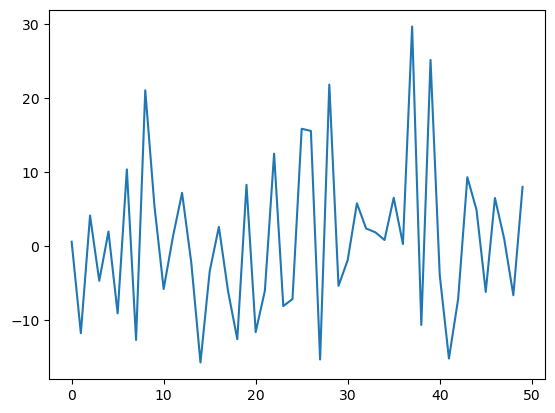

```
1-element Array{PyCall.PyObject,1}:
 PyObject <matplotlib.lines.Line2D object at 0x000000004D215AF0>
```

```julia
foos = 10*randn(50)
plot(foos)
```

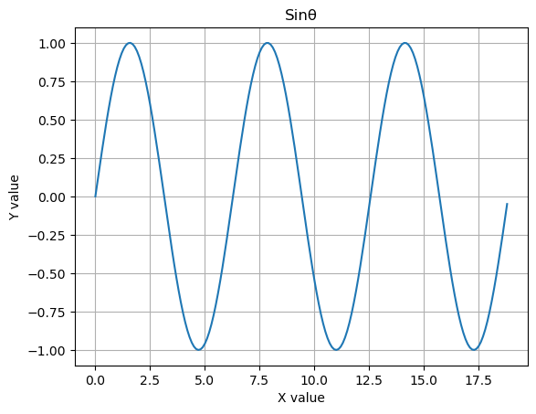

```julia
x = range(0,step=0.1,stop=6*π)
y = sin.(x)
plot(x, y)
xlabel("X value")
ylabel("Y value")
PyPlot.title("Sinθ")
grid("on")
```

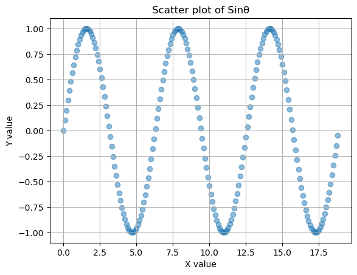

```julia
scatter(x,y,alpha=0.5)
xlabel("X value")
ylabel("Y value")
PyPlot.title("Scatter plot of Sinθ")
grid("on")
```

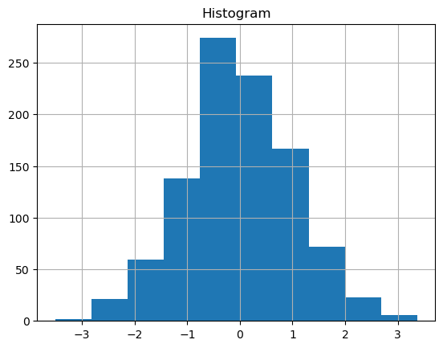

```julia
PyPlot.plt.hist(randn(1000),bins=10); # Histogram
PyPlot.title("Histogram")
grid("on")
```

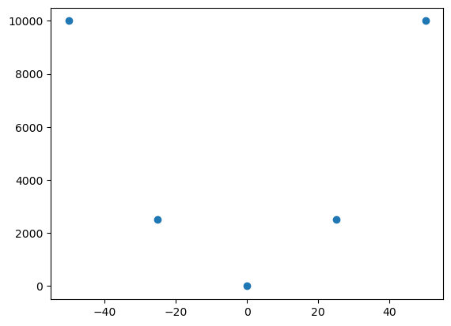

```julia
f(x) = 4*x.^2
x = [-50,-25,0,25,50]
scatter(x,f(x));
```

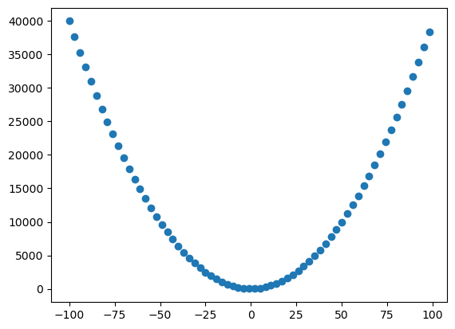

```julia
xx = range(-100, stop =100, step=3)
scatter(xx,f(xx));
```